# COVID Intervention Effects - Mainland China Case Study

Eric Fan

10/22/2021

```r
library(tidyverse)
library(readr)
library(lubridate)
library(tseries)
library(zoo)
```

# Introduction

In this notebook, I will analyze the effects of the two main public policies aimed at curbing COVID cases: stay-at-home orders and facial-covering requirements.

The Oxford COVID-19 Government Response Tracker (OxCGRT) records Chinese provincial governments’ policy responses to COVID-19 since January 2020 on a daily basis. The data show stringent COVID policies across China in the early months of 2020, followed by the localisation of restrictions in response to small outbreaks in subsequent months. Some of my research decisions are informed by a recent [exploratory analysis](https://www.bsg.ox.ac.uk/sites/default/files/2021-06/BSG-WP-2021-041.pdf) of this dataset. Full documentation of the OxCGRT dataset is [here](https://github.com/OxCGRT/covid-policy-tracker/blob/master/documentation/interpretation_guide.md).

There are several advantages of using this dataset from China:

- A nice baseline for province-based analysis: After the first outbreak of COVID-19 in Wuhan, Hubei Province in December 2019, mainland China effectively extinguished all nation-wide transmission of COVID-19 in a few months. Since May 2020, there has been only small pockets of localized outbreaks. Compared to data from the US and most other countries, cases from China after May 2020 did not show nation-side seasonality.
- Good variety of COVID policies from provincial governments: Provincial governments have significant autonomy to choose their own policies according to a centrally defined tiered-risk system. For example, some provinces implemented measures to prevent the risks associated with the 2021 Chinese New Year travel season, others did not elevate their stringency level if no local transmission was found.
- Reliable policy enforcement: Stay-at-home orders and facial-covering requirements have been strictly enforced in all parts of China. Non-compliance is rare, either because the public generally supports COVID restrictions or because the punishment for non-compliance is severe. In any case, we won’t need to worry too much about non-compliance being an issue in this analysis.
- Reliable testings: Every time a local transmission is reported, entire cities and towns get tested for COVID, such as in the initial [Wuhan](https://apnews.com/article/health-china-coronavirus-pandemic-wuhan-8fa8edb073629c692ac51772e5e9d775) outbreak and later in [other local outbreaks](https://www.theguardian.com/world/2021/aug/02/china-tests-millions-as-nanjing-airport-outbreak-sees-covid-cases-surge). These mass-testings are mandatory and usually repeated multiple rounds within a week. Testing and treating capacities were never overwhelmed, except for the initial outbreak in Wuhan, which is excluded from this analysis. Therefore, we won’t need to worry too much about testing discrepancies/biases in this analysis.
- No herd immunity: If a big portion of a community already got COVID before, then that immunity would reduce the number of new cases regardless of policy interventions. Luckily, no community in China has had enough cases to reach any meaningful herd immunity (not even in Wuhan), so we won’t need to worry about biases caused by herd immunity.

Note that it takes time for stay-at-home orders and mask mandates to show their effects, so I will predict the effects of these interventions based on COVID cases from a week later.

In summary, we have:

- Region: Mainland China
- Unit of Analysis: Date
- Interventions: Stay-at-home orders and facial-covering requirements.
- Outcome: Number of COVID cases (rolling average in the following week)
- Controlling for: Province (as dummy variable)

# Daily Covid Cases

For daily COVID cases in China, I will use the COVID-19 Data Repository by the Center for Systems Science and Engineering (CSSE) at Johns Hopkins University. Data source and full documentation [here](https://github.com/CSSEGISandData/COVID-19). Their China data are collected from the National Health Commission of the People’s Republic of China (NHC) and China CDC (CCDC).

```r
# load data
time_series_covid19_confirmed_global <- read_csv("C:/Users/fanxi/OneDrive/Columbia/Frontiers of Computational Journalism/COVID_causality_assignment/time_series_covid19_confirmed_global.csv")
```

Now let’s clean up the data and take a look.

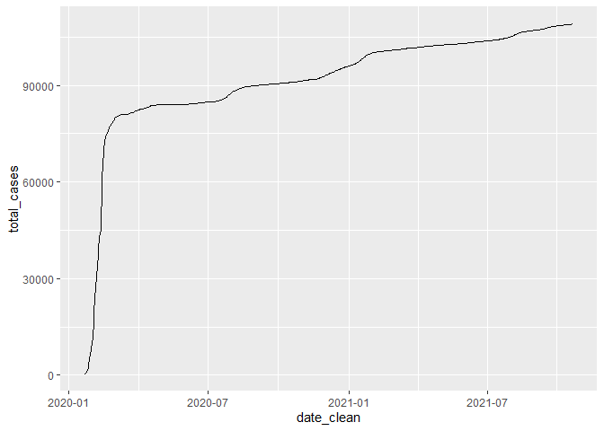

```r
# data cleaning
covidCases_china <- time_series_covid19_confirmed_global %>%
  filter(`Country/Region` == 'China') %>% # filter out data on China only
  select(-c('Lat','Long', `Country/Region`)) %>% # remove unnecessary columns
  gather("date", "cases", 2:640) %>% # transform this wide dataset into a long dataset
  mutate(date_clean = mdy(date)) %>% # standardize dates
  rename(province = `Province/State`) # rename for later joining

# plot all cases
covidCases_china %>%
  group_by(date_clean) %>%
  summarise(total_cases = sum(cases)) %>%
  ggplot(aes(x=date_clean, y=total_cases)) +
  geom_line()
```

As shown above, the data comes in as cumulative case numbers on a non-stationary time series. I must calculate the daily new cases and make the data more stationary before running a regression.

## Clean up time series and transform data

First, we need to calculate the daily new cases.

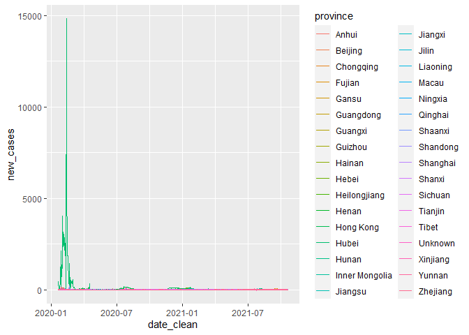

```r
# calculate new daily cases for each province
covidCases_china <- covidCases_china %>%
  group_by(province) %>%
  arrange(province) %>%
  mutate(new_cases = cases - lag(cases,  default = 0))

covidCases_china %>%
  group_by(province) %>%
  ggplot(aes(x=date_clean, y=new_cases, color = province)) +
  geom_line()
```

I’ll focus on the period after the initial nation-wide spread and before vaccinations began. Therefore, I filter the data for only the time frame from May 2020 to July 2021.

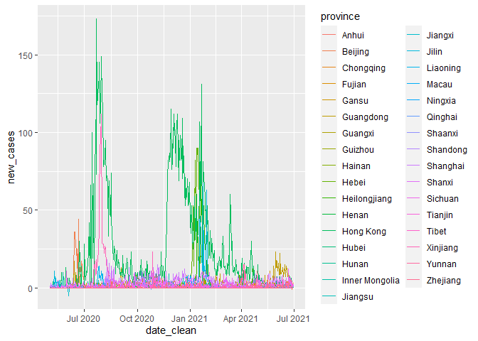

```r
# filter dates
covidCases_china_May2020 <- covidCases_china %>%
  filter(date_clean > '2020-05-01' & date_clean < '2021-07-01') %>%
  filter(province != 'Unknown')

# let's plot the cases out by province!
covidCases_china_May2020 %>%
  group_by(province) %>%
  ggplot(aes(x=date_clean, y=new_cases, color = province)) +
  geom_line()
```

Next step is to make the time series more stationary and shift the data to give the policy interventions one week to take effect. I also use a 7-day rolling average instead of just daily numbers, to smooth out the distribution.

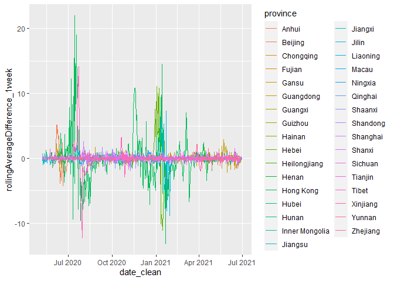

```r
# let's do a simple differencing to "stationarize" the time series
covidCases_china_May2020 <- covidCases_china_May2020 %>%
  group_by(province) %>%
  arrange(province) %>%
  mutate(differece = (new_cases - lag(new_cases,  default = 0)))

# calculate the 7-day rolling average and give it a 7-day lead. When I mathch interventions with this data, the date of each policy intervention will correspond to the average change in new COVID cases in the next week. This will effectively give policy interventions 7-days to take effect.
covidCases_china_May2020 <- covidCases_china_May2020 %>%
  group_by(province) %>%
  arrange(province) %>%
  mutate(rollingAverageDifference_1week = rollapply(lead(differece, n=7, default = 0),7,mean,align='right',fill=NA))

# let's plot em out!
covidCases_china_May2020 %>%
  group_by(province) %>%
  ggplot(aes(x=date_clean, y=rollingAverageDifference_1week, color = province)) +
  geom_line()
```

By taking a one-day difference, I’m now measuring the **change** in new cases from day to day. I argue that this is a better measurement than just the absolute number of cases, since we want to know the ability for policy interventions to decrease/increase case growth. Here’s how I will interpret the “rollingAverageDifference_1week” variable: the average acceleration in new daily COVID cases in the next 7 days.

# Policy Intervention Data (OxCGRT)

As discussed in the introduction, I will use data from the Oxford COVID-19 Government Response Tracker (OxCGRT). Full documentation of the OxCGRT dataset is [here](https://github.com/OxCGRT/covid-policy-tracker/blob/master/documentation/interpretation_guide.md).

Specifically, I will use three variables:

- **C6_Stay at home requirements** where 0 means no policy, 1 means recommended, 2 means ‘essential’ trips only, 3 means required with minimal exceptions.
- **H6_Facial Coverings** reflects policies on the use of facial coverings outside the home, where 0 means no policy, 1 means recommended, 2 means required at some in-door public places, 3 means required at all in-door public places, 4 means Required at all public places (including outside) regardless of other people.
- **EconomicSupportIndex** measures economic support policies in each province, including E1 (Income support for households) and E2 (debt relief).

```r
# load data
OxCGRT <- read_csv("C:/Users/fanxi/OneDrive/Columbia/Frontiers of Computational Journalism/COVID_causality_assignment/OxCGRT_latest.csv",
    col_types = cols(RegionCode = col_character(),
        RegionName = col_character()))
```

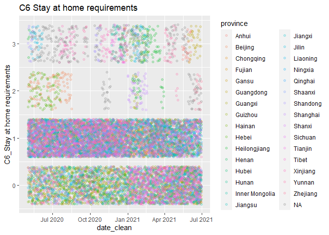

```r
# clean data
interventions <- OxCGRT %>%
  filter(CountryName == 'China') %>% # filter out China data
  mutate(date_clean = ymd(Date)) %>% # clean dates
  rename(province = `RegionName`) %>% # rename for later joining
  filter(date_clean > '2020-05-01' & date_clean < '2021-07-01') %>%
  select(province, date_clean, `C6_Stay at home requirements`, `H6_Facial Coverings`,EconomicSupportIndex) # select relevant indices

# let's plot out C6_Stay at home requirements
interventions %>%
  group_by(province) %>%
  ggplot(aes(x=date_clean, y=`C6_Stay at home requirements`, color = province)) +
  geom_jitter(alpha = 0.2) +
  labs(title="C6 Stay at home requirements")
```

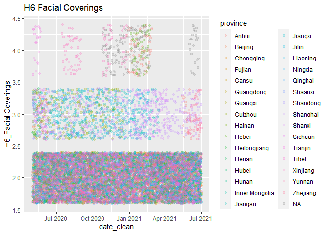

```r
# let's plot out H6_Facial Coverings
interventions %>%
  group_by(province) %>%
  ggplot(aes(x=date_clean, y=`H6_Facial Coverings`, color = province)) +
  geom_jitter(alpha = 0.2) +
  labs(title="H6 Facial Coverings")
```

As shown above, all provinces have maintained at least a level-2 facial covering requirement throughout the period. As a result, our baseline for regression would be the level-2 facial covering requirement.

Note that both C6 and H6 are categorical variables represented with integer values. I jitter the points only to better visualize the distributions.

# Regression and Casual Inference

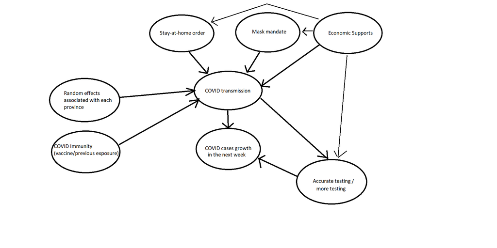

Casual Graph

A key part of producing casual inference is to figure out the chicken-and-eggs problem. Luckily, I have avoided this reverse causation problem by giving my dependent measurement (COVID cases growth) a one-week delay. As shown in the above graph, we can be confident that future cases cannot affect current policies.

As discussed in the introduction, we can safely assume that testings were done quickly and comprehensively. However, we should not control for testing anyway because it does not affect the independent variables therefore not a confounder.

However, Economic support policies could be a confounder, as it could potentially help the mask and stay-at-home mandates, help with testing efforts (giving people more resources to take time off, for example), and reduce COVID transmissions. I will control for this variable using the OxCGRT’s **EconomicSupportIndex**.

I will also control for province-based random effects by turning each province into a dummy variable.

```r
# join intervention data with COVID cases data
data_joined <- covidCases_china_May2020 %>%
  inner_join(interventions, by = c("province", "date_clean"))
```

```r
# Run regression
lm <- lm(rollingAverageDifference_1week ~ as.factor(`C6_Stay at home requirements`)+as.factor(`H6_Facial Coverings`)+province+EconomicSupportIndex, data = data_joined)
summary(lm)
```

```
##
## Call:
## lm(formula = rollingAverageDifference_1week ~ as.factor(`C6_Stay at home requirements`) +
##     as.factor(`H6_Facial Coverings`) + province + EconomicSupportIndex,
##     data = data_joined)
##
## Residuals:
##      Min       1Q   Median       3Q      Max
## -11.9372  -0.0466  -0.0037   0.0052  14.4914
##
## Coefficients:
##                                              Estimate Std. Error t value
## (Intercept)                                 0.0488612  0.0274010   1.783
## as.factor(`C6_Stay at home requirements`)1  0.0274323  0.0198480   1.382
## as.factor(`C6_Stay at home requirements`)2 -0.2187229  0.0374497  -5.840
## as.factor(`C6_Stay at home requirements`)3 -0.1958413  0.0309111  -6.336
## as.factor(`H6_Facial Coverings`)3           0.0706284  0.0237209   2.977
## as.factor(`H6_Facial Coverings`)4          -0.2392339  0.0431088  -5.550
## provinceBeijing                            -0.0210680  0.0415490  -0.507
## provinceChongqing                          -0.0751541  0.0418024  -1.798
## provinceFujian                             -0.0651051  0.0412212  -1.579
## provinceGansu                              -0.0712902  0.0405942  -1.756
## provinceGuangdong                          -0.0536572  0.0403721  -1.329
## provinceGuangxi                            -0.0417067  0.0368684  -1.131
## provinceGuizhou                            -0.0866189  0.0384719  -2.251
## provinceHainan                             -0.0522815  0.0369333  -1.416
## provinceHebei                               0.0367876  0.0371840   0.989
## provinceHeilongjiang                       -0.0247562  0.0414816  -0.597
## provinceHenan                              -0.0742242  0.0418907  -1.772
## provinceHubei                              -0.0801595  0.0421085  -1.904
## provinceHunan                              -0.0478152  0.0368605  -1.297
## provinceInner Mongolia                     -0.0482396  0.0385342  -1.252
## provinceJiangsu                            -0.1189453  0.0434806  -2.736
## provinceJiangxi                            -0.0751347  0.0417853  -1.798
## provinceJilin                              -0.0935760  0.0436818  -2.142
## provinceLiaoning                           -0.0491945  0.0368909  -1.334
## provinceNingxia                            -0.0691221  0.0399113  -1.732
## provinceQinghai                            -0.0743185  0.0415751  -1.788
## provinceShaanxi                            -0.0657572  0.0422767  -1.555
## provinceShandong                           -0.0355796  0.0394493  -0.902
```

[output cut: 39 more lines]

```
## provinceShanxi                              0.02310 *
## provinceSichuan                             0.22892
## provinceTianjin                             0.19036
## provinceTibet                               0.09735 .
## provinceXinjiang                            0.28564
## provinceYunnan                              0.20274
## provinceZhejiang                            0.10726
## EconomicSupportIndex                        0.89964
## ---
## Signif. codes:  0 '***' 0.001 '**' 0.01 '*' 0.05 '.' 0.1 ' ' 1
##
## Residual standard error: 0.5258 on 12942 degrees of freedom
##   (196 observations deleted due to missingness)
## Multiple R-squared:  0.01372,    Adjusted R-squared:  0.01097
## F-statistic: 4.999 on 36 and 12942 DF,  p-value: < 2.2e-16
```

Note that all the coefficients we got in this multiple variable regression are pretty small in absolute value. This is expected, as outbreaks in China were quickly controlled to single-digit transmissions and there was zero new COVID case in the vast majority of days.

I got an intercept of 0.049, meaning that the average case growth in the next week in the Anhui Province is expected to accelerate by 0.049, given that there were no economic support, no at home requirement, and level-2 mask mandate (required at some in-door public places).

I got a coefficients of -0.22 for level-2 Stay-at-home requirement, meaning that the policy decreases average case growth in the next week 0.22, controlling for all other variables.

I got a coefficients of -0.20 for level-3 Stay-at-home requirement, meaning that the policy decreases average case growth in the next week by 0.20, controlling for all other variables.

I got a coefficients of -0.24 for level-4 facial covering requirement, meaning that the policy decreases average case growth in the next week by 0.24, controlling for all other variables.

These coefficient are all statistically significant at 95% level and have the largest absolute effect sizes among all other coefficients.

I got no significant results for level-1 Stay-at-home requirement or economic support index.

Strangely, I got a positive coefficient 0.0706284 for level-3 facial covering. I think this might be caused by the missing of level-1 and level-2 data. It is likely that level-3 facial covering is not significantly different from level-2, and by bad luck we got this small but positive coefficient that is moderately significant p value of 0.0029.

Let’s plot the 95% confidence intervals:

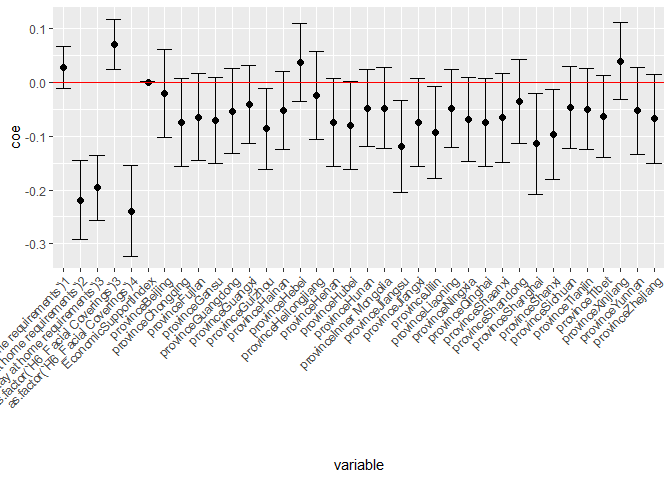

```r
conf <- as.data.frame(confint(lm))

conf <- conf %>%
  rownames_to_column('variable') %>%
  mutate(coe=coef(lm)) %>%
  filter(variable != '(Intercept)')

names(conf) <- c('variable', 'low', 'high', 'coe')

conf %>%
  ggplot(aes(x = variable, y = coe)) +
  geom_point(size = 2) +
  geom_errorbar(aes(ymax = high, ymin = low)) +
  geom_hline(yintercept=0, color = "red") +
  theme(axis.text.x = element_text(angle = 45, vjust = 1, hjust=1))
```

Overall, I conclude that stay-at-home orders and facial-covering requirements were effective in reducing COVID cases in China. However, there could be several things missing from this analysis:

- I didn’t have any observations of level-1 and level-2 facial covering policies.
- The one-week shift might not be perfect. It is unclear to me how much time delay we should add into the data to make the estimation most accurate.
- There might be other confounding variables, such as international travel patterns and supply chain transmissions. A future study may want to separate cases introduced from abroad (about half of all cases in China) from domestic transmissions. The effect of these domestic intervention policies are better estimated with only domestic cases.
- There might correlations between difference provinces. For example, local authorities tend to tighten COVID controls if there is an outbreak in a neighboring province. Cross-provincial transmissions were rare, but it did happen a few times, such as in the case of the [Nanjing outbreak](https://www.bbc.com/news/world-asia-china-58052894).